# ShinyApp: Predict Diamond Carat from Price

July 17, 2018

## Predict Diamond Carat from Price

This Shiny app was created to predict the carat of a dimond, based on the price that the customer is willing to pay.

The user can simply move the slider left and right, select the price he/she is willing to pay for a diamond, and find out what its carat would be. The calculation is done in the Plot section.

This Shiny app uses the Diamonds dataset, pre-loaded in R. The monetary limit ranges from $300 to $20,000. As a default price has been chosen $5,051, as the average spending limit preffered by a customer.

## Files accessibility

Now that you know what the app does, don't hesitate to give it a try. You can access the interactive version on ShinyApp.io, or check out all the project files (including the one for the current presentation) on GitHub.

**Link to the app on ShinyApp.io:**

https://kaloatanasov.shinyapps.io/courseProjectApp/

**Link to the project files on GitHub:**

https://github.com/kaloatanasov/JHU-Developing-Data-Products-Course-Project-Shiny-App

## Modeling data

The ShinyApp uses Nonlinear Least Squares model for more accurate prediction of diamond carat.

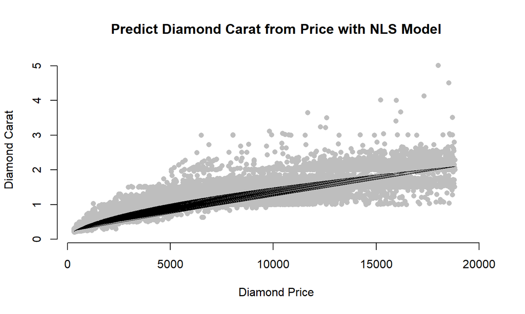

## Diamonds dataset credits

*Prices of 50,000 round cut diamonds*

*Description:*

*A dataset containing the prices and other attributes of almost 54,000 diamonds.*

*Usage:*

*diamonds*

*Format:*

*A data frame with 53940 rows and 10 variables.*